# Project#5 of AI Course of University of Tehran

Rasta Tadayon - 810196436

## Image Classification Using Neural Networks and Pytorch

#### Brief Description of The Project

In this project the objective is categorizing images into 52 categories of goods such as shoes, Tshirts, accessories, etc. To do so Neural Networks are used and during the project effects of diferent parameters are evaluated on the network. For implementation of the network Pytorch library of Python is used. The input images are given via google drive and are unzipped and used in the learning process.

#### **Neural Networks**

Neural networks are a set of algorithms, modeled loosely after the human brain, that are designed to recognize patterns. Just like the neural network in human brain, Artificial Neural Network consists of neurons (nodes) and connections between those neurons. Nodes in a neral network are grouped into layers. The layers between the input layer and output layer are called hidden layers. The connections of the biological neuron are modeled as weights in the artifial network. In the layers, output of a neuron is the input to the later neuron. To calculate the output of a neural network the propagation function computes the input to a neuron from the outputs of its predecessor neurons and their connections as a weighted sum. Each node can also have a bias term which is added to the weighted sum in order to make the model fit better to a given data.

```python
from google.colab import drive
!unzip -n "drive/My Drive/categorized_products.zip"
```

[output not shown]

[output cut: 4945 more lines]

[output not shown]

The images are unzipped using the given line of code.

```python
import torchvision
import torch
import matplotlib.pyplot as plt
from torch.utils.data import Dataset, DataLoader, random_split
from torchvision.datasets import ImageFolder
from torch.utils.data.sampler import SubsetRandomSampler
import torchvision.transforms as transforms
import numpy as np
import operator
from sklearn.model_selection import train_test_split
import torch.nn as nn
import torch.nn.functional as F
from datetime import timedelta
from datetime import datetime
from copy import deepcopy
```

## **PART 1** : Visualizing the Data set

```python
class CustomToTensor(object):
    """Convert PIL Images in sample to pytorch Tensors."""

    ## the input image must be grayscaled first
    def __call__(self, image):
        image = np.array(image, dtype=np.float32)
        # numpy image: H x W
        return torch.from_numpy(image)
```

After the images are loaded transforms are applied to them. In this project for simplicity gray scale tranform is applied to eliminate the effect of colors in the learning process. Also in this part a custom transform is applied to the images which makes the image array into 32bit floating point numpy array and then creates a tensor object from that array and returns the tensor object.

```python
transform = transforms.Compose([transforms.Grayscale(), CustomToTensor()])
image_datasets = ImageFolder(root= "categorized_products", transform=transform)
```

```python
image_datasets[7]
```

```
(tensor([[255., 255., 255.,  ..., 255., 255., 255.],
         [255., 255., 255.,  ..., 255., 255., 255.],
         [255., 255., 255.,  ..., 255., 255., 255.],
         ...,
         [255., 255., 255.,  ..., 255., 255., 255.],
         [255., 255., 255.,  ..., 255., 255., 255.],
         [255., 255., 255.,  ..., 255., 255., 255.]]), 0)
```

```python
dataloaders = torch.utils.data.DataLoader(image_datasets, batch_size=32, shuffle=True, num_workers=32)
```

In order to obain a data sructure that is iterable and also in the learning process can be parallelised the `torch.utils.data.DataLoader` is used. Using dataloaders make taking advantage of GPU possible therfore makes the learning time significantly less.

```python
classes = image_datasets.classes
data_iter = iter(dataloaders)
data_iter.next()
images, labels = data_iter.next()
```

As mentioned before the images are classified into 52 unique classes. In this part for 12 unique classes of the total 52 classes, one picture is shown for each which represents that class.

```
{'Nightdress', 'Flip Flops', 'Dupatta', 'Tshirts', 'Earrings', 'Sandals', 'Casual Shoes', 'Heels', 'Tops', 'Kajal and Eyeliner', 'Watches', 'Kurtis'}
```

[figure not shown]

```python
PRINTING = 12
unique_goods = set()
image_indexes = []
for i in range(len(labels)):
  if classes[labels[i]] not in unique_goods:
    unique_goods.add(classes[labels[i]])
    image_indexes.append(i)
    if(len(unique_goods) == 12):
      break

print(unique_goods)

def imshow(img_array, labels, classes):
    f, axs = plt.subplots(2, 6, figsize = (20,10))

    for i in range(2):
      for j in range(6):
        axs[i][j].imshow(img_array[i * 6 + j], cmap='gray')
        axs[i][j].set_title(classes[labels[i * 6 + j]])
        axs[i][j].axis('off')
    plt.show()

imshow(images[image_indexes], labels[image_indexes], classes)
```

## **PART 2**

### **2-a : Visualising Number of Given Samples In Each Class**

In this part number of given pictures for each class in the dataset is calculated and a bar plot representing them is drawn which can be seen bellow.

```python
def get_number_distribution(loader, classes):
  total_category_count = {classes[i] : 0 for i in range(len(classes))}
  for _, labels in loader:
    for label in labels:
      total_category_count[ classes[label] ] += 1
  return total_category_count

number_of_each_class = get_number_distribution(dataloaders, classes)
sorted_list = sorted(number_of_each_class.items(), key=lambda x: x[1], reverse=False)
sorted_dict = {sorted_list[i][0] : sorted_list[i][1] for i in range (len(sorted_list))}
```

```
<BarContainer object of 52 artists>
```

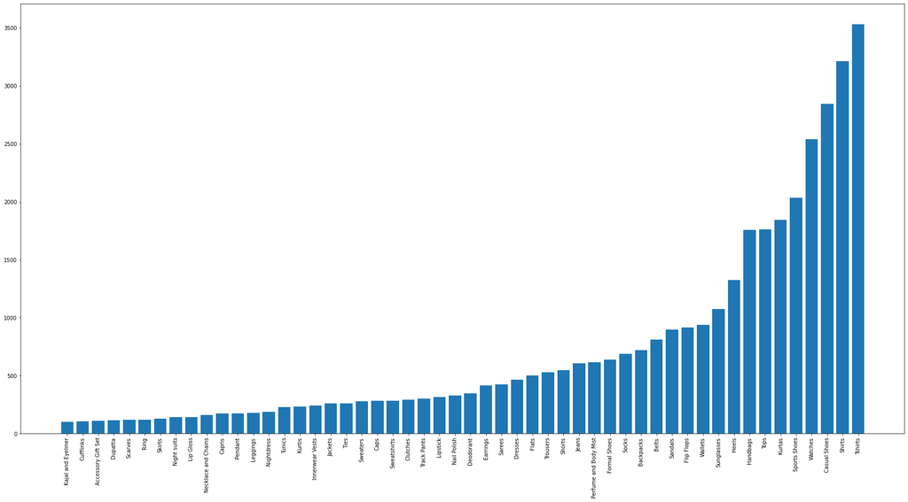

```python
keys = sorted_dict.keys()
values = sorted_dict.values()

f, ax = plt.subplots(figsize=(30,15))
plt.xticks(rotation=90)
plt.bar(keys, values)
# plt.figure(figsize=(20,10))
# plt.xticks(rotation='vertical')
```

It is observable that the dataset does not have a uniform distribution and some classes are much better represented (like T-shirts) than others (such as Kajal and Eyeliner)

### **2-b : Splitting Data into Train and Test Set**

In this part the dataset is split into test and train set. To do so for each class 80% of its data will be placed by random in the train set and 20% will be placed in the test set. An alternative for this splitting action is to take 80% of the whole dataset and put it in the train set and 20% in the test set however this may cause for a class not to be presented well in the train set therfore the model will not be able to have a good accuracy on that specific class.

For the splitting the `sklearn.model_selection.train_test_split()` function is used which does the task that we want done.

```python
X = image_datasets
y = image_datasets.targets
X_train, X_test, y_train, y_test = train_test_split(X, y, stratify=y, test_size=0.2)
```

```python
train_loader = torch.utils.data.DataLoader(X_train, batch_size=64,
                                          shuffle=True, num_workers=32)

test_loader = torch.utils.data.DataLoader(X_test, batch_size=64,
                                         shuffle=False, num_workers=32)
```

## **PART 3** : Creating the Neual Network Model

The neural network is created by setting the number of neruons in each layer and setting the activation function for each layer as well. For the number of input and output nodes in each layer I have scaled the number of the nodes in the recitation file since the image size of this project was three times of the recitations. For the number of total layer 5 was decided to be just like the recitation and it was observed later that this number works pretty well.

The `forward()` function reshapes its input, x, to a tensor with x.size columns and appropriate rows per columns then if forwards x through the network.

```python
class Model(nn.Module):
    def __init__(self, class_num, act=F.relu):
        super(Model, self).__init__()


        self.layer1 = nn.Linear(1 * 60 * 80, 12 * 60 * 20) # layer 1 input: 4800   output: 14400
        self.act1 = act


        self.layer2 = nn.Linear(12 * 60 * 20, 30 * 14 * 10) # layer 2 input: 14400  output: 4200
        self.act2 = act



        self.layer3 = nn.Linear(30 * 14 * 10, 70 * 30 * 1) # layer 3 input: 4200    output: 2100
        self.act3 = act


        self.layer4 = nn.Linear(70 * 30 * 1, 250 * 2 *1)  # layer 4 input: 2100     output: 500
        self.act4 = act

        self.layer5 = nn.Linear(250 * 2 *1, class_num)    # layer 5 input: 500      output: 52

    def forward(self, x):

        x = x.view(x.size(0), -1)

        x = self.layer1(x)
        x = self.act1(x)

        x = self.layer2(x)
        x = self.act2(x)

        x = self.layer3(x)
        x = self.act3(x)

        x = self.layer4(x)
        x = self.act4(x)

        x = self.layer5(x)
        return x
```

```python
device = torch.device("cuda:0" if torch.cuda.is_available() else "cpu")
print(device)
```

```
cuda:0
```

### **3-a : Counting the Number of Trainable Parameters in the Network**

The function `count_parameters()` counts the parameters of the model that can be trained. In this model those are the weights and biases. For counting of the parameters the `named_parameters()` function is used.

```python
model = Model(len(classes))
model = model.to(device)
learning_rate = 0.01
epoch_num = 10
criterion = nn.CrossEntropyLoss()
optimizer = torch.optim.SGD(model.parameters(), lr=learning_rate)
```

Hyperpatameters used for the training are like follows:

- Learning rate = 0.01
- Number of epoches = 10
- Loss Criterion = Cross Entropy
- Activation Funcrtion = Relu
- Optimizer = Stochastic Gradient Descent

**Cross Entropy**

This criterion is useful when training a classification problem with C classes. Pytorch documentation of it can be found [here](https://pytorch.org/docs/master/generated/torch.nn.CrossEntropyLoss.html).

**ReLU**

ReLU is short for Rectified Linear Unit and works like this:

`if (x > 0) return x else return 0`

```python
def count_parameters(model):
    total_param = 0
    for name, param in model.named_parameters():
        if param.requires_grad:
            num_param = np.prod(param.size())
            if param.dim() > 1:
                print(name, ':', 'x'.join(str(x) for x in list(param.size())), '=', num_param)
            else:
                print(name, ':', num_param)
            total_param += num_param
    return total_param

count_parameters(model)
```

```
layer1.weight : 14400x4800 = 69120000
layer1.bias : 14400
layer2.weight : 4200x14400 = 60480000
layer2.bias : 4200
layer3.weight : 2100x4200 = 8820000
layer3.bias : 2100
layer4.weight : 500x2100 = 1050000
layer4.bias : 500
layer5.weight : 52x500 = 26000
layer5.bias : 52
```

```
139517252
```

As mentioned before the connection of neurons are modeled as weights in the Artificial Network and the network is fully connected. Also each node has a bias value. Therefore each layer has [number of input nodes][number of out put nodes] weights and [number of layer nodes] bias values. Summation of all the weight and bias values of each layer will produce the total number of trainable parameters in the network.

```python
def fit(model, train_loader, device, criterion, optimizer, num_epochs=epoch_num):

  total_time = 0.
  average_losses = []
  for epoch in range(num_epochs):
      train_loss = 0.
      d1 = datetime.now()
      for images, labels in train_loader:

        images = images.to(device)
        labels = labels.to(device)

        # Clear gradients w.r.t. parameters
        optimizer.zero_grad()

        # Forward pass to get output/logits
        outputs = model(images)

        # Calculate Loss: softmax --> cross entropy loss
        loss = criterion(outputs, labels)

        # Getting gradients w.r.t. parameters
        loss.backward()

        # Updating parameters
        optimizer.step()
        train_loss += loss.item()

      average_loss = train_loss / len(train_loader)
      average_losses.append(average_loss)
      d2 = datetime.now()
      delta = d2 - d1
      seconds = float(delta.total_seconds())
      total_time += seconds
      print('epoch %d, train_loss: %.3f, time elapsed: %s seconds' % (epoch + 1, average_loss, seconds))
  print('total training time: %.3f minutes' % (total_time / 60))
  return average_losses
```

```python
average_losses = fit(model, train_loader, device, criterion, optimizer, epoch_num)
```

```
epoch 1, train_loss: nan, time elapsed: 28.411884 seconds
epoch 2, train_loss: nan, time elapsed: 28.391406 seconds
epoch 3, train_loss: nan, time elapsed: 28.341156 seconds
epoch 4, train_loss: nan, time elapsed: 28.369054 seconds
epoch 5, train_loss: nan, time elapsed: 28.338613 seconds
epoch 6, train_loss: nan, time elapsed: 28.347467 seconds
epoch 7, train_loss: nan, time elapsed: 28.352602 seconds
epoch 8, train_loss: nan, time elapsed: 28.361017 seconds
epoch 9, train_loss: nan, time elapsed: 28.313779 seconds
epoch 10, train_loss: nan, time elapsed: 28.549559 seconds
total training time: 4.730 minutes
```

```python
def test_model_accuracy(model, test_loader):
    # Calculate Accuracy
    correct = 0.
    total = 0.
    # Iterate through test dataset
    with torch.no_grad():
      for images, labels in test_loader:
        outputs = model(images.to(device))
        _, predicted = torch.max(outputs.data, 1)
        total += labels.size(0)
        correct += (predicted.to('cpu') == labels).sum().item()

    accuracy = 100 * correct / total
    return accuracy
```

```python
print("Model weights: \n", model.layer1.weight, model.layer2.weight, model.layer3.weight, model.layer4.weight)
```

```
Model weights:
 Parameter containing:
tensor([[-1.0517e+02, -1.0517e+02, -1.0517e+02,  ..., -1.0516e+02,
         -1.0517e+02, -1.0518e+02],
        [-1.7685e-02, -1.1231e-02, -3.6037e-03,  ..., -1.2308e-02,
         -1.9633e-02, -1.2739e-02],
        [-1.2006e-02, -1.3028e-02, -3.5702e-02,  ..., -3.5055e-02,
         -1.0376e-02, -1.7686e-02],
        ...,
        [-2.4841e-03,  1.0650e-02, -4.4594e-03,  ..., -6.4150e-03,
          4.6961e-03,  5.6886e-03],
        [-9.8002e-03,  9.2433e-03,  5.8585e-03,  ...,  3.1980e-03,
          9.1596e-03, -5.9518e-03],
        [-2.4132e-02, -4.0504e-02, -4.5502e-02,  ..., -3.1615e-02,
         -4.6707e-02, -2.6174e-02]], device='cuda:0', requires_grad=True) Parameter containing:
tensor([[nan, nan, nan,  ..., nan, nan, nan],
        [nan, nan, nan,  ..., nan, nan, nan],
        [nan, nan, nan,  ..., nan, nan, nan],
        ...,
        [nan, nan, nan,  ..., nan, nan, nan],
        [nan, nan, nan,  ..., nan, nan, nan],
        [nan, nan, nan,  ..., nan, nan, nan]], device='cuda:0',
       requires_grad=True) Parameter containing:
tensor([[nan, nan, nan,  ..., nan, nan, nan],
        [nan, nan, nan,  ..., nan, nan, nan],
        [nan, nan, nan,  ..., nan, nan, nan],
        ...,
        [nan, nan, nan,  ..., nan, nan, nan],
        [nan, nan, nan,  ..., nan, nan, nan],
        [nan, nan, nan,  ..., nan, nan, nan]], device='cuda:0',
       requires_grad=True) Parameter containing:
tensor([[nan, nan, nan,  ..., nan, nan, nan],
        [nan, nan, nan,  ..., nan, nan, nan],
        [nan, nan, nan,  ..., nan, nan, nan],
        ...,
        [nan, nan, nan,  ..., nan, nan, nan],
        [nan, nan, nan,  ..., nan, nan, nan],
        [nan, nan, nan,  ..., nan, nan, nan]], device='cuda:0',
       requires_grad=True)
```

```python
print('train set accuracy: ', test_model_accuracy(model, train_loader))

print('test set accuracy: ', test_model_accuracy(model, test_loader))
```

```
train set accuracy:  0.29866774052820566
test set accuracy:  0.2953020134228188
```

```python
def confusion_matrix(model, data_loader, class_num):
  confusion_matrix = np.zeros(shape=(class_num,class_num))
  #vertical is for the actual label and horizontal is for the prediction
  with torch.no_grad():
    for images, labels in data_loader:
      outputs = model(images.to(device))
      _, predicted = torch.max(outputs.data, 1)
      for i in range(labels.size(0)):
        confusion_matrix[labels[i]][predicted[i]] += 1
  return confusion_matrix
```

```python
train_cm = confusion_matrix(model, train_loader, len(classes))
test_cm = confusion_matrix(model, test_loader, len(classes))
```

It is observable above that the train loss values are "nan" which means they are so large that they can not fit into a number or something like log(0) and therefore are not a number. The reason why the loss values are nan is because the tensor values are not normalized and are between [0, 255]. When training loss becomes NaN it could be a sign of **Gradient explosion**.

Gradient explosion happens in deep networks or recurrent neural networks when gradients can accumulate (sometimes exponentially) during an update and result in very large gradients. These in turn result in large updates to the network weights, which result in an unstable network. At an extreme, the values of weights can become so large as to overflow and result in NaN values. The weights are printed above and can be seen that have become nan values.

This is the most probable cause in this part. Because of this problem the model is not learning at all therefore predicting class 0 for all of the inputs. (the reason for that is the `max` function returns the first value if the arguments are of the same value resulting in the class 0 prediction.)

```python
def accuracy_for_each_class(confusion_matrix):
  total = sum(sum(confusion_matrix))
  accuracy = [0] * len(confusion_matrix)
  temp = 0
  for i in range(len(confusion_matrix)):
    # accuracy[i] = (total - (sum(confusion_matrix[:][i]) +
    #                        sum(confusion_matrix[i][:]) - 2 * confusion_matrix[i][i])) / total * 100
    accuracy[i] = confusion_matrix[i][i]/sum(confusion_matrix[i][:]) * 100
  return accuracy
```

```python
def plot_bar_chart(train_accuracy, test_accuracy):
  barWidth = 0.35
  r1 = np.arange(len(classes))
  r2 = [x + barWidth for x in r1]
  f, ax = plt.subplots(figsize=(20,10))
  plt.bar(r1, train_accuracy, color='#7f6d5f', width=barWidth, edgecolor='white', label='train set')
  plt.bar(r2, test_accuracy, color='#557f2d', width=barWidth, edgecolor='white', label='test set')

  # Add xticks on the middle of the group bars
  plt.xlabel('classes', fontweight='bold')
  plt.xticks([r + barWidth for r in range(len(train_accuracy))], classes, rotation = 90)
  plt.ylabel('accuracy values', fontweight='bold')

  # Create legend & Show graphic
  plt.legend()
  plt.show()
```

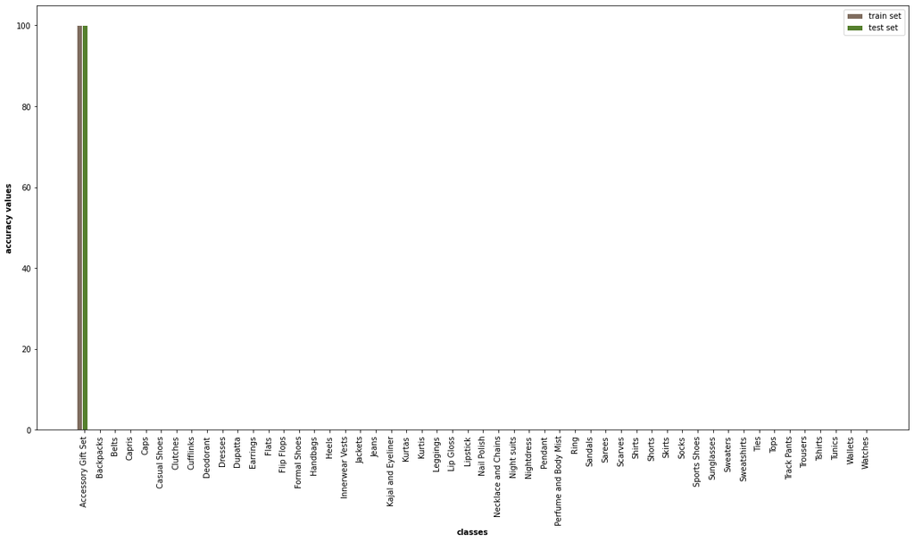

```python
train_accuracy = accuracy_for_each_class(train_cm)
test_accuracy = accuracy_for_each_class(test_cm)
plot_bar_chart(train_accuracy, test_accuracy)
```

Since all of the input images are classified as the class zero aka Accessory Gift Set, the accuracy for this class is 100 and for all the other classes the accuracy value equals to zero.

```python
def plot_avarage_loss(average_losses):
  f, ax = plt.subplots(figsize=(15,7.5))
  plt.plot(average_losses)
  plt.xlabel('epoch', fontweight='bold')
  plt.ylabel('train loss values', fontweight='bold')
  plt.title('train loss in different epoches')
  plt.xticks(np.arange(0, len(average_losses)+1))
```

[figure not shown]

```python
plot_avarage_loss(average_losses)
```

## **PART 4** : Normalizing the Images

In this part a new transform is defined which brings the values of image tensor from 0-255 to 0-1 thus normalizing and restricting the values the input vector can have. Normalization changes the numeric values of the tensor image to a common scale without distoting differenecs in the ranges of values.

Normalizing the data often results in faster convergance. Also in this part it is observable that since the values have been restricted to be between 0 and 1 the gradient explosion does not happen and the model is able to train.

```python
class custom_to_tensor(object):
    """Convert PIL Images in sample to pytorch Tensors."""

    ## the input image must be grayscaled first
    def __call__(self, image):
        image = np.array(image, dtype=np.float32)/255
        # numpy image: H x W
        return torch.from_numpy(image)
```

```python
transform_4 = transforms.Compose([transforms.Grayscale(), custom_to_tensor()])
image_datasets4 = ImageFolder(root= "categorized_products", transform =transform_4)
```

```python
X_4 = image_datasets4
y_4 = image_datasets4.targets
X_train_4, X_test_4, y_train_4, y_test_4 = train_test_split(X_4, y_4, stratify=y_4, test_size=0.2)
train_loader_4 = torch.utils.data.DataLoader(X_train_4, batch_size=64,
                                          shuffle=True, num_workers=32)

test_loader_4 = torch.utils.data.DataLoader(X_test_4, batch_size=64,
                                         shuffle=False, num_workers=32)
```

```python
model_4 = Model(len(classes))
model_4 = model_4.to(device)

optimizer_4 = torch.optim.SGD(model_4.parameters(), lr=learning_rate)

average_losses_4 = fit(model_4, train_loader_4, device, criterion, optimizer_4, epoch_num)
```

```
epoch 1, train_loss: 3.340, time elapsed: 29.748936 seconds
epoch 2, train_loss: 2.643, time elapsed: 29.667097 seconds
epoch 3, train_loss: 2.184, time elapsed: 29.636077 seconds
epoch 4, train_loss: 1.886, time elapsed: 29.628867 seconds
epoch 5, train_loss: 1.725, time elapsed: 29.670861 seconds
epoch 6, train_loss: 1.595, time elapsed: 29.657403 seconds
epoch 7, train_loss: 1.501, time elapsed: 29.686437 seconds
epoch 8, train_loss: 1.440, time elapsed: 29.631407 seconds
epoch 9, train_loss: 1.362, time elapsed: 29.72213 seconds
epoch 10, train_loss: 1.317, time elapsed: 29.596215 seconds
total training time: 4.944 minutes
```

```python
print('train: ', test_model_accuracy(model_4, train_loader_4))
print('test: ', test_model_accuracy(model_4, test_loader_4))
```

```
train:  59.324138393905834
test:  59.54362416107382
```

```python
train_cm_4 = confusion_matrix(model_4, train_loader_4, len(classes))
test_cm_4 = confusion_matrix(model_4, test_loader_4, len(classes))
train_accuracy_4 = accuracy_for_each_class(train_cm_4)
test_accuracy_4 = accuracy_for_each_class(test_cm_4)
plot_bar_chart(train_accuracy_4, test_accuracy_4)
```

[output not shown]

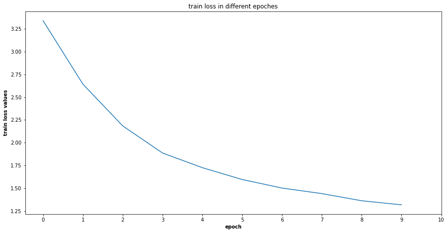

```python
plot_avarage_loss(average_losses_4)
```

## **PART 5** : Initializing Weights to Zero

In this part all the weights including biases are initialized to zero using the `model.apply()` function. This function applies a given function recursively to every submodule (as returned by .children() ) as well as self (model itself).

```python
def zeros_(m):
    if(type(m) == nn.Linear):
      nn.init.zeros_(m.weight)
      m.bias.data.fill_(0)

model_5 = Model(len(classes))
model_5 = model_5.to(device)

model_5.apply(zeros_)

optimizer_5 = torch.optim.SGD(model_5.parameters(), lr=learning_rate)

average_losses_5 = fit(model_5, train_loader_4, device, criterion, optimizer_5, epoch_num)
```

```
epoch 1, train_loss: 3.896, time elapsed: 28.521039 seconds
epoch 2, train_loss: 3.798, time elapsed: 28.418951 seconds
epoch 3, train_loss: 3.720, time elapsed: 28.316382 seconds
epoch 4, train_loss: 3.661, time elapsed: 28.372107 seconds
epoch 5, train_loss: 3.616, time elapsed: 28.328638 seconds
epoch 6, train_loss: 3.582, time elapsed: 28.311965 seconds
epoch 7, train_loss: 3.557, time elapsed: 28.330364 seconds
epoch 8, train_loss: 3.538, time elapsed: 28.605722 seconds
epoch 9, train_loss: 3.524, time elapsed: 28.441788 seconds
epoch 10, train_loss: 3.513, time elapsed: 28.348902 seconds
total training time: 4.733 minutes
```

```python
print('5- train: ', test_model_accuracy(model_5, train_loader_4))
print('5- test: ', test_model_accuracy(model_5, test_loader_4))
```

```
5- train:  9.48689553340716
5- test:  9.48993288590604
```

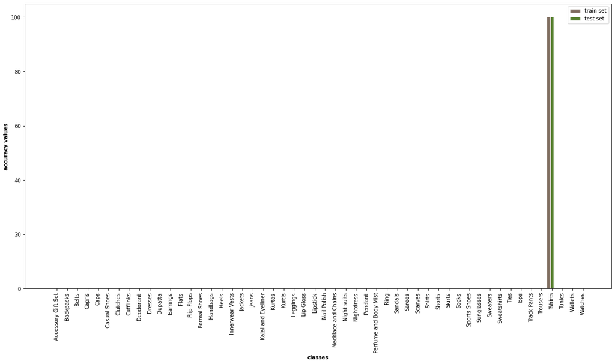

```python
train_cm_5 = confusion_matrix(model_5, train_loader_4, len(classes))
test_cm_5 = confusion_matrix(model_5, test_loader_4, len(classes))
train_accuracy_5 = accuracy_for_each_class(train_cm_5)
test_accuracy_5 = accuracy_for_each_class(test_cm_5)
plot_bar_chart(train_accuracy_5, test_accuracy_5)
```

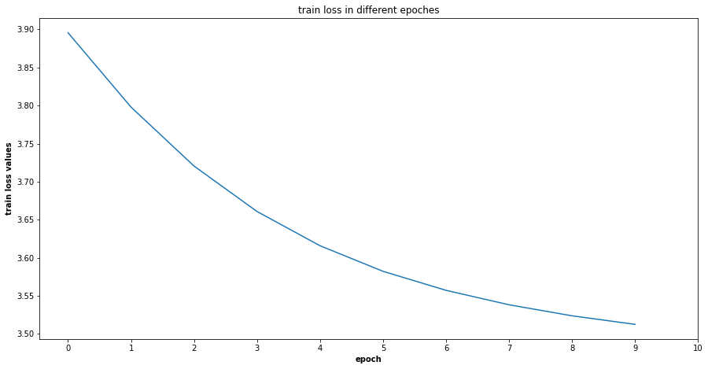

```python
plot_avarage_loss(average_losses_5)
```

```python
model_5.layer5.bias
```

```
Parameter containing:
tensor([-4.8700e-01,  7.1963e-02,  1.4865e-01, -4.2571e-01, -3.2390e-01,
         1.4415e+00, -3.1689e-01, -4.9163e-01, -2.6371e-01, -1.5682e-01,
        -4.8214e-01, -1.9865e-01, -1.2416e-01,  2.3558e-01, -1.6660e-03,
         8.5392e-01,  5.5185e-01, -3.6253e-01, -3.4739e-01, -2.8007e-02,
        -4.9523e-01,  9.0883e-01, -3.6955e-01, -4.2294e-01, -4.5533e-01,
        -2.9366e-01, -2.8027e-01, -4.3973e-01, -4.5778e-01, -4.1258e-01,
        -4.2563e-01, -2.3913e-02, -4.8070e-01,  2.1878e-01, -1.9317e-01,
        -4.8100e-01,  1.5935e+00, -8.1118e-02, -4.7114e-01,  4.0700e-02,
         1.0256e+00,  3.6017e-01, -3.2839e-01, -3.2139e-01, -3.4371e-01,
         8.5615e-01, -3.0539e-01, -9.6796e-02,  1.7074e+00, -3.7453e-01,
         2.5117e-01,  1.2984e+00], device='cuda:0', requires_grad=True)
```

```python
max(model_5.layer5.bias)
```

```
tensor(1.7074, device='cuda:0', grad_fn=<SelectBackward>)
```

It is observable that initializing weights to zero is not a good idea and does not result in good accuracy. The reasoning is as follows:

When all the weights are initialized with 0, the derivative with respect to loss function is the same for every value in weight vector, thus all weights have the same value in subsequent iterations. This makes hidden units symmetric and continues for all the n iterations i.e. setting weights to 0 does not make it better than a linear model. Also biases do not have any effect since they are zero as well. This means initializing all the weights with zeros leads the neurons to learn the same features during training.

Here all of the weights of the network are not changed during the training and are zero after the training is done except for the bias values of the output layer. The reason for that is during back propagation the gradients are multiplied by the weights of network therefore are always zero. Except the bias value of the last layer which is updated by the gradient of error function. Resulting the class with the highest number of data to have larger bias and for the network to predict every input into that class

## **5-b** : The Best Way to Initialize Weights

As mentioned before initializing weights to zero will result in a model that does not fit our data very well. Any constant value that the weights are all set to will make all the nodes learn the same features therefore is not a good option. Other options are to **randomly** initialize the weights.

When initializing weights randomly one thing to be aware of is that if weights are initialized to high values or very low values what happens and also what is a reasonable initialization of weight values.

- **A too-large initialization leads to exploding gradients** : This means when the weight values are too large the values of activation increase exponentially. When these activations are used in backward propagation, this leads to the gradients of the cost with the respect to the parameters being too big. This leads the cost to oscillate around its minimum value.
- **A too-small initialization leads to vanishing gradients** : This means when the weight values are too small values of the activation decrease exponentially. When these activations are used in backward propagation, this leads to the vanishing gradient problem. The gradients of the cost with respect to the parameters are too small, leading to convergence of the cost before it has reached the minimum value.

**Better Weight Initialization Methods**:

- **Using ReLu / leaky ReLU as the activation function**: These activation functions are relatively robust to the vanishing/exploding gradient issues
- **Using heuristic to initialize the wights depending on the non linear activation function**: for **ReLu** the randomly generated weight values are multiplied by np.sqrt(2/size_l-1). For **Tanh** the heuristic is called **Xavier Initialization**. in this one the randomly generated values are multiplied by np.sqrt(1/size_l-1)
- **Gradient Clipping**: This is another way of dealing with the exploding gradient problem. The objective is setting a threshold value and if a chosen function of gradient is larger than this threshold, it will be set to another value.

Also using an already learnt network's weights is a possible way of initializing the weight values specially for general and large networks.

## **PART 6** : Chacking Different Learning Rates

```python
def check_learning_rates(learning_rate):
  print('Learning Rate = ', learning_rate)
  model_6 = Model(len(classes))
  model_6 = model_6.to(device)
  optimizer_6 = torch.optim.SGD(model_6.parameters(), lr=learning_rate)
  average_losses_6 = fit(model_6, train_loader_4, device, criterion, optimizer_6, epoch_num)

  test_acc = test_model_accuracy(model_6, test_loader_4)
  train_acc = test_model_accuracy(model_6, train_loader_4)

  print('\nAccuracy:\nTest: ', test_acc, '\nTrain: ', train_acc)
  train_cm_6 = confusion_matrix(model_6, train_loader_4, len(classes))
  test_cm_6 = confusion_matrix(model_6, test_loader_4, len(classes))
  train_accuracy_6 = accuracy_for_each_class(train_cm_6)
  test_accuracy_6 = accuracy_for_each_class(test_cm_6)


  plot_bar_chart(train_accuracy_6, test_accuracy_6)
  plot_avarage_loss(average_losses_6)

  return train_acc, test_acc, average_losses_6
```

```
Learning Rate =  0.002
epoch 1, train_loss: 3.711, time elapsed: 28.762222 seconds
epoch 2, train_loss: 3.431, time elapsed: 28.983655 seconds
epoch 3, train_loss: 3.348, time elapsed: 28.927186 seconds
epoch 4, train_loss: 3.134, time elapsed: 29.023916 seconds
epoch 5, train_loss: 2.900, time elapsed: 28.941613 seconds
epoch 6, train_loss: 2.740, time elapsed: 28.92485 seconds
epoch 7, train_loss: 2.608, time elapsed: 28.900933 seconds
epoch 8, train_loss: 2.484, time elapsed: 28.93106 seconds
epoch 9, train_loss: 2.358, time elapsed: 28.987188 seconds
epoch 10, train_loss: 2.242, time elapsed: 29.017901 seconds
total training time: 4.823 minutes

Accuracy:
Test:  36.16107382550336
Train:  34.9642605456559
```

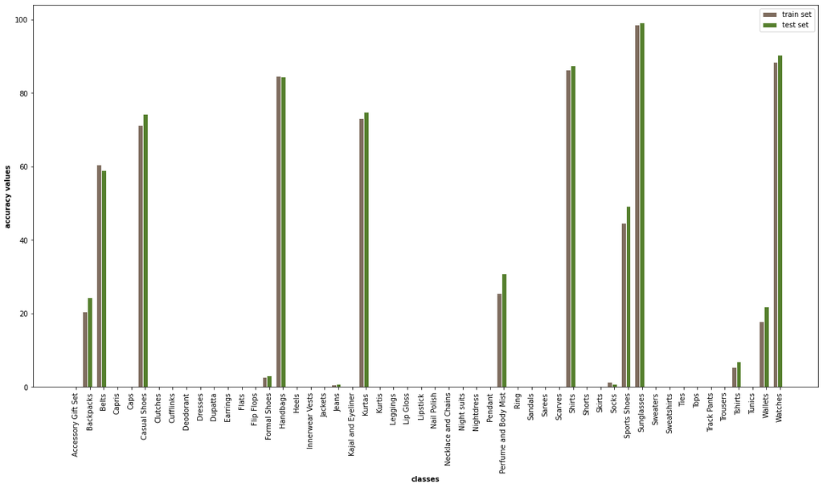

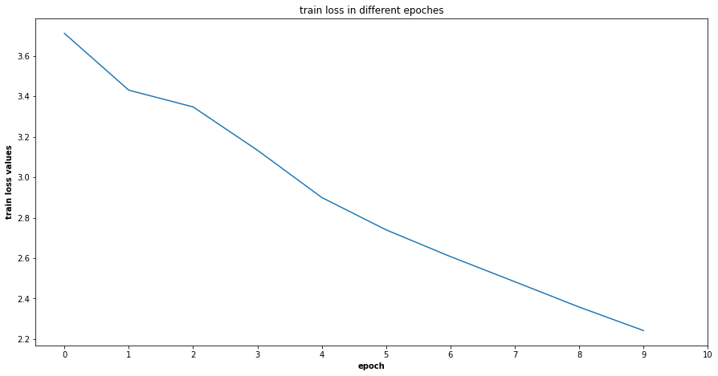

```python
train_acc_002, test_acc_002, average_losses_002 = check_learning_rates(0.002)
```

```
Learning Rate =  0.004
epoch 1, train_loss: 3.597, time elapsed: 28.947661 seconds
epoch 2, train_loss: 3.265, time elapsed: 29.229406 seconds
epoch 3, train_loss: 2.849, time elapsed: 29.056729 seconds
epoch 4, train_loss: 2.577, time elapsed: 29.086961 seconds
epoch 5, train_loss: 2.359, time elapsed: 28.981931 seconds
epoch 6, train_loss: 2.186, time elapsed: 29.124366 seconds
epoch 7, train_loss: 2.013, time elapsed: 29.109255 seconds
epoch 8, train_loss: 1.896, time elapsed: 29.215428 seconds
epoch 9, train_loss: 1.770, time elapsed: 29.16863 seconds
epoch 10, train_loss: 1.683, time elapsed: 29.192245 seconds
total training time: 4.852 minutes

Accuracy:
Test:  42.87248322147651
Train:  42.69606362629619
```

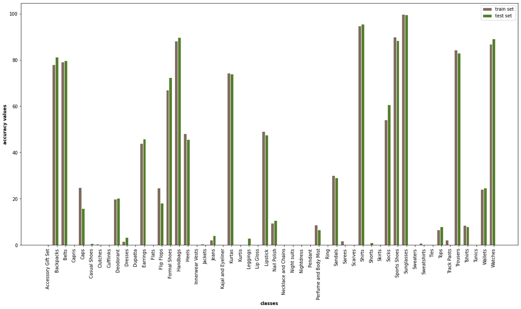

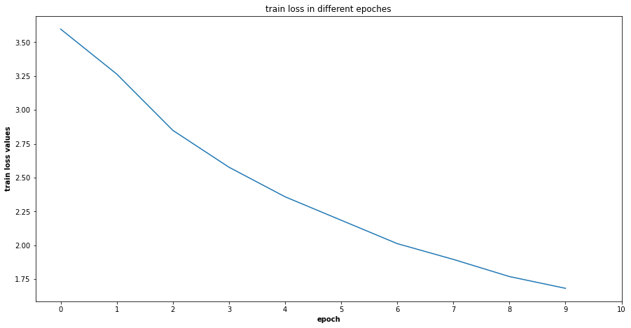

```python
train_acc_004, test_acc_004, average_losses_004 = check_learning_rates(0.004)
```

```
Learning Rate =  0.006
epoch 1, train_loss: 3.503, time elapsed: 28.978716 seconds
epoch 2, train_loss: 2.971, time elapsed: 29.166229 seconds
epoch 3, train_loss: 2.545, time elapsed: 29.134574 seconds
epoch 4, train_loss: 2.274, time elapsed: 29.165233 seconds
epoch 5, train_loss: 2.019, time elapsed: 29.098268 seconds
epoch 6, train_loss: 1.837, time elapsed: 29.308626 seconds
epoch 7, train_loss: 1.698, time elapsed: 29.200219 seconds
epoch 8, train_loss: 1.612, time elapsed: 29.121845 seconds
epoch 9, train_loss: 1.533, time elapsed: 28.99142 seconds
epoch 10, train_loss: 1.465, time elapsed: 29.11168 seconds
total training time: 4.855 minutes

Accuracy:
Test:  54.442953020134226
Train:  53.93805161247022
```

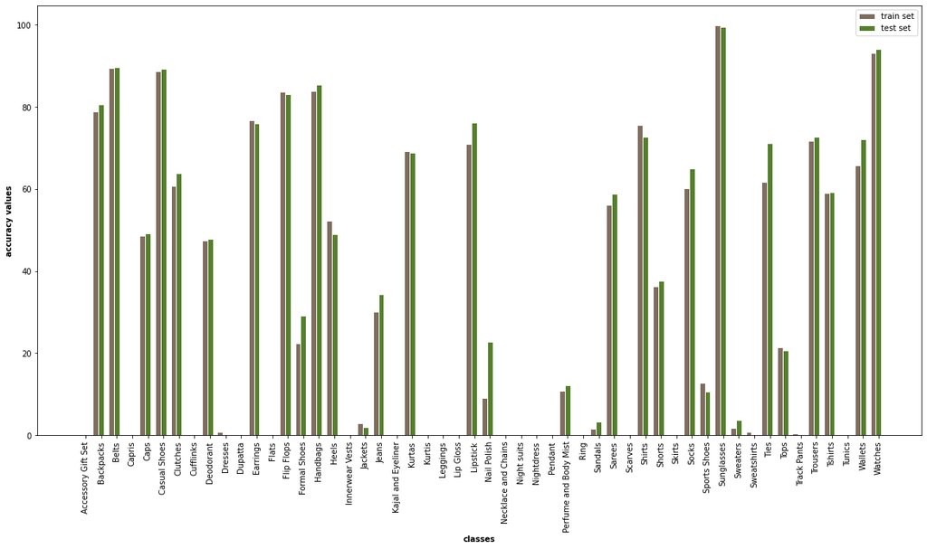

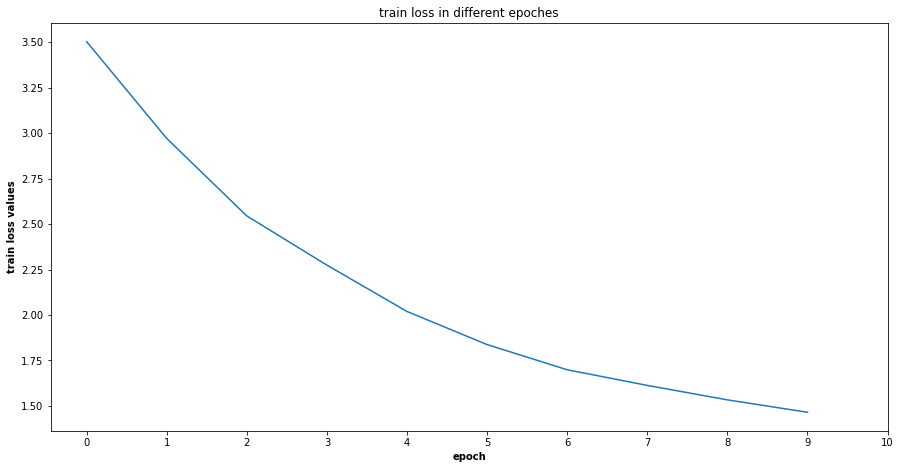

```python
train_acc_006, test_acc_006, average_losses_006 = check_learning_rates(0.006)
```

```
Learning Rate =  0.008
epoch 1, train_loss: 3.426, time elapsed: 28.838327 seconds
epoch 2, train_loss: 2.755, time elapsed: 29.103861 seconds
epoch 3, train_loss: 2.339, time elapsed: 28.970559 seconds
epoch 4, train_loss: 2.001, time elapsed: 29.106189 seconds
epoch 5, train_loss: 1.788, time elapsed: 29.003365 seconds
epoch 6, train_loss: 1.657, time elapsed: 29.079253 seconds
epoch 7, train_loss: 1.555, time elapsed: 29.034074 seconds
epoch 8, train_loss: 1.482, time elapsed: 29.092816 seconds
epoch 9, train_loss: 1.419, time elapsed: 29.529868 seconds
epoch 10, train_loss: 1.360, time elapsed: 29.239812 seconds
total training time: 4.850 minutes

Accuracy:
Test:  54.966442953020135
Train:  54.38773113191718
```

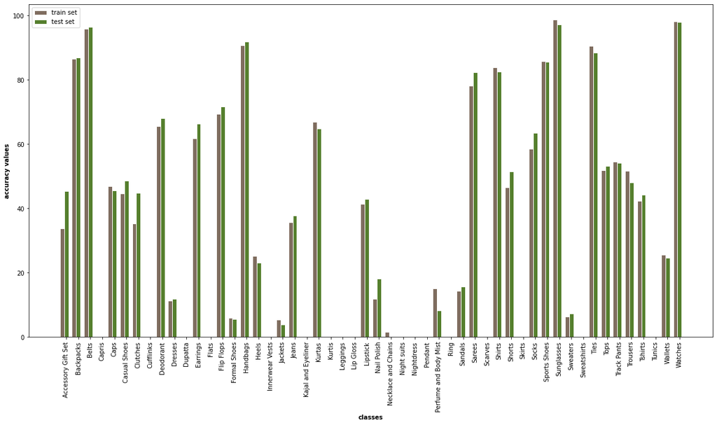

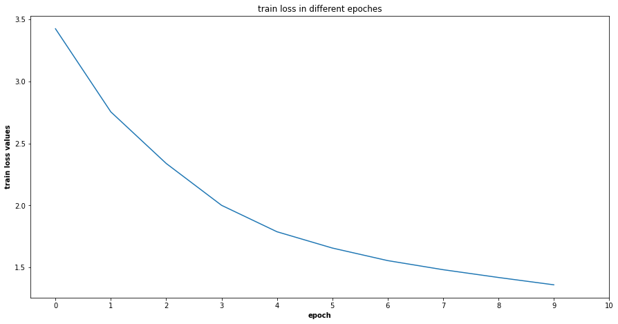

```python
train_acc_008, test_acc_008, average_losses_008 = check_learning_rates(0.008)
```

```
Learning Rate =  0.01
epoch 1, train_loss: 3.371, time elapsed: 28.788452 seconds
epoch 2, train_loss: 2.635, time elapsed: 29.013476 seconds
epoch 3, train_loss: 2.171, time elapsed: 28.878388 seconds
epoch 4, train_loss: 1.877, time elapsed: 28.970199 seconds
epoch 5, train_loss: 1.704, time elapsed: 31.102084 seconds
epoch 6, train_loss: 1.581, time elapsed: 29.021281 seconds
epoch 7, train_loss: 1.499, time elapsed: 28.914194 seconds
epoch 8, train_loss: 1.426, time elapsed: 28.99254 seconds
epoch 9, train_loss: 1.353, time elapsed: 28.906563 seconds
epoch 10, train_loss: 1.322, time elapsed: 28.994031 seconds
total training time: 4.860 minutes

Accuracy:
Test:  59.63758389261745
Train:  60.032215846169336
```

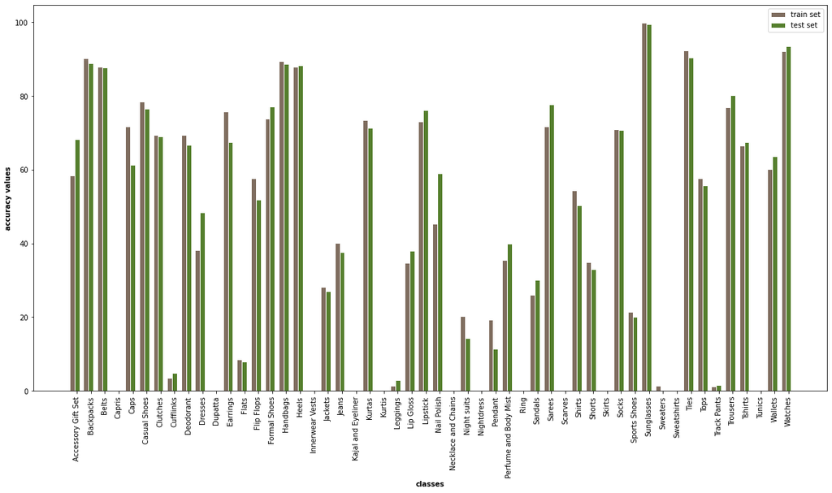

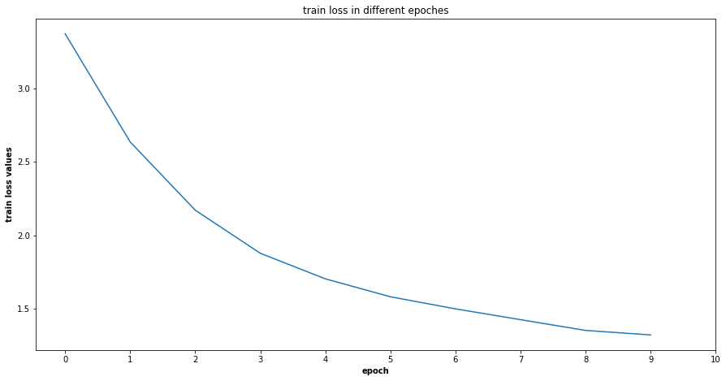

```python
train_acc_01, test_acc_01, average_losses_01 = check_learning_rates(0.01)
```

```
Learning Rate =  0.03
epoch 1, train_loss: 2.901, time elapsed: 28.825599 seconds
epoch 2, train_loss: 2.038, time elapsed: 28.964577 seconds
epoch 3, train_loss: 1.721, time elapsed: 28.874232 seconds
epoch 4, train_loss: 1.517, time elapsed: 28.991936 seconds
epoch 5, train_loss: 1.389, time elapsed: 28.894512 seconds
epoch 6, train_loss: 1.291, time elapsed: 29.020015 seconds
epoch 7, train_loss: 1.214, time elapsed: 28.86737 seconds
epoch 8, train_loss: 1.156, time elapsed: 29.132322 seconds
epoch 9, train_loss: 1.105, time elapsed: 28.910787 seconds
epoch 10, train_loss: 1.063, time elapsed: 28.988605 seconds
total training time: 4.824 minutes

Accuracy:
Test:  60.53691275167785
Train:  60.26041142320212
```

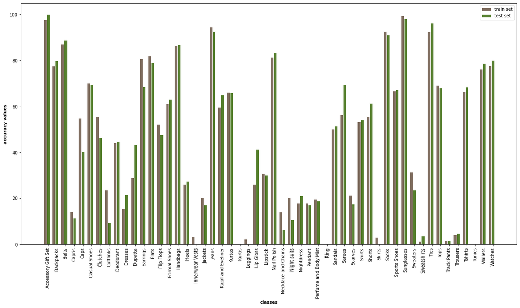

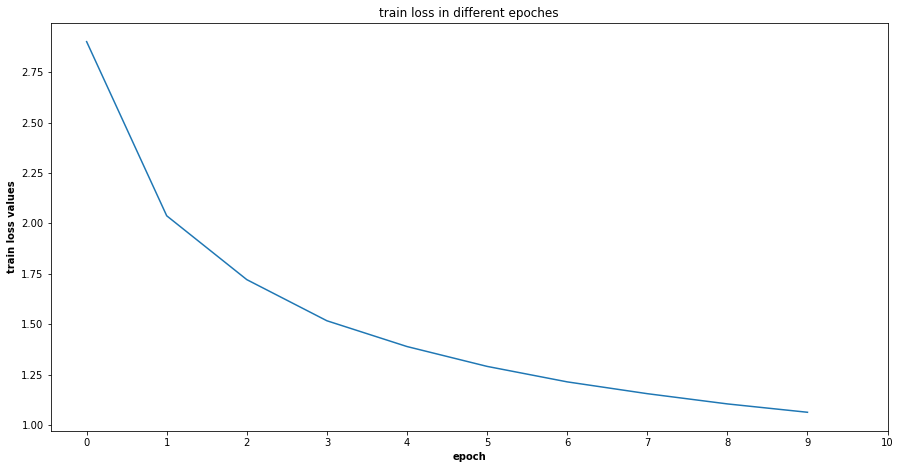

```python
train_acc_03, test_acc_03, average_losses_03 = check_learning_rates(0.03)
```

```
Learning Rate =  0.05
epoch 1, train_loss: 2.766, time elapsed: 28.796994 seconds
epoch 2, train_loss: 1.983, time elapsed: 28.95618 seconds
epoch 3, train_loss: 1.648, time elapsed: 28.792942 seconds
epoch 4, train_loss: 1.432, time elapsed: 28.901689 seconds
epoch 5, train_loss: 1.327, time elapsed: 28.758304 seconds
epoch 6, train_loss: 1.231, time elapsed: 28.828342 seconds
epoch 7, train_loss: 1.154, time elapsed: 28.780081 seconds
epoch 8, train_loss: 1.108, time elapsed: 28.916936 seconds
epoch 9, train_loss: 1.046, time elapsed: 28.745109 seconds
epoch 10, train_loss: 1.008, time elapsed: 28.90992 seconds
total training time: 4.806 minutes

Accuracy:
Test:  63.11409395973154
Train:  62.95513272257458
```

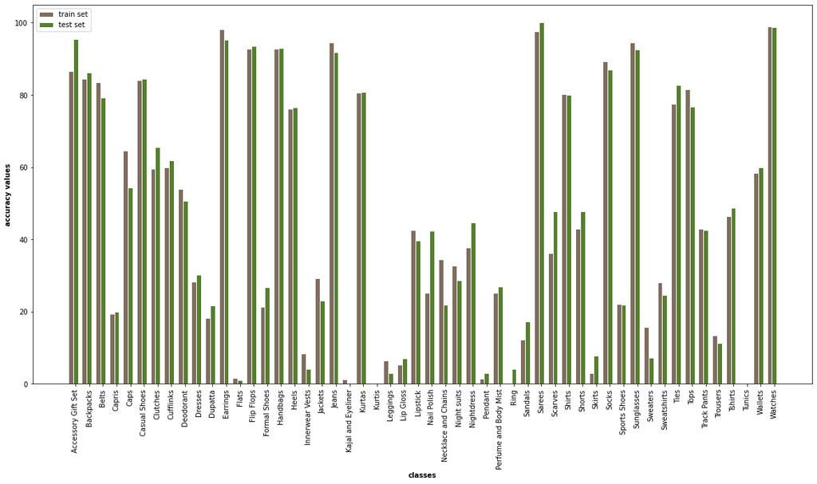

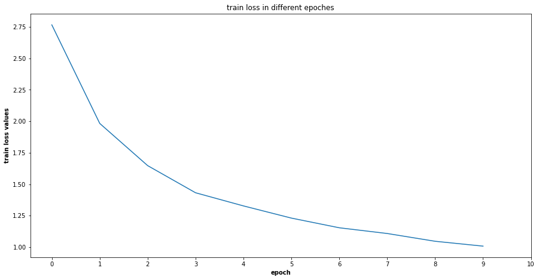

```python
train_acc_05, test_acc_05, average_losses_05 = check_learning_rates(0.05)
```

```
Learning Rate =  0.07
epoch 1, train_loss: 2.753, time elapsed: 28.648234 seconds
epoch 2, train_loss: 2.030, time elapsed: 28.800217 seconds
epoch 3, train_loss: 1.681, time elapsed: 28.812786 seconds
epoch 4, train_loss: 1.457, time elapsed: 29.1216 seconds
epoch 5, train_loss: 1.336, time elapsed: 28.992828 seconds
epoch 6, train_loss: 1.245, time elapsed: 29.274403 seconds
epoch 7, train_loss: 1.172, time elapsed: 29.031648 seconds
epoch 8, train_loss: 1.121, time elapsed: 29.108612 seconds
epoch 9, train_loss: 1.052, time elapsed: 28.911707 seconds
epoch 10, train_loss: 1.011, time elapsed: 29.059412 seconds
total training time: 4.829 minutes

Accuracy:
Test:  64.91275167785236
Train:  65.28071411792342
```

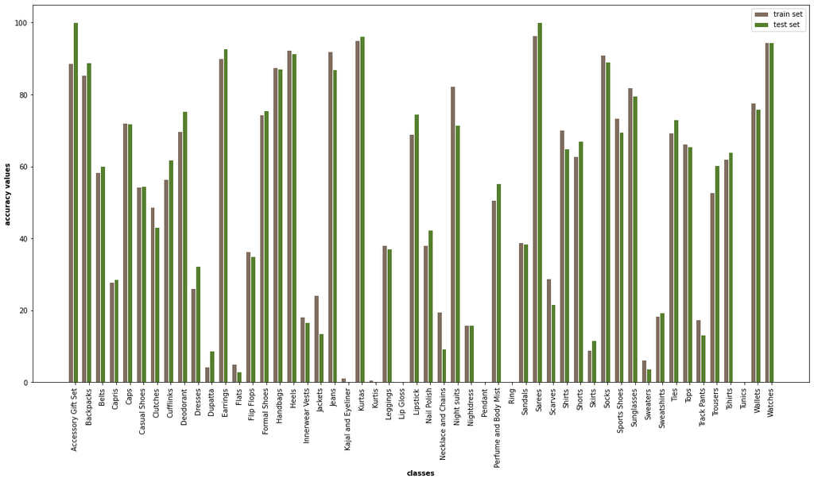

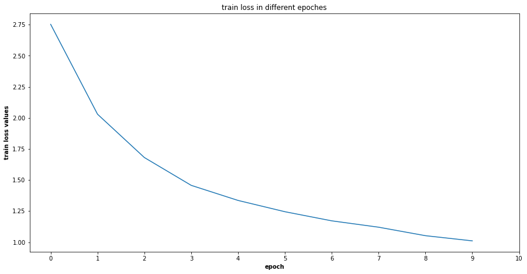

```python
train_acc_07, test_acc_07, average_losses_07 = check_learning_rates(0.07)
```

```
Learning Rate =  0.09
epoch 1, train_loss: 2.859, time elapsed: 28.82537 seconds
epoch 2, train_loss: 2.046, time elapsed: 28.979144 seconds
epoch 3, train_loss: 1.715, time elapsed: 28.951748 seconds
epoch 4, train_loss: 1.492, time elapsed: 28.994971 seconds
epoch 5, train_loss: 1.359, time elapsed: 28.974125 seconds
epoch 6, train_loss: 1.252, time elapsed: 28.954379 seconds
epoch 7, train_loss: 1.185, time elapsed: 28.899833 seconds
epoch 8, train_loss: 1.129, time elapsed: 28.854496 seconds
epoch 9, train_loss: 1.064, time elapsed: 30.019376 seconds
epoch 10, train_loss: 1.017, time elapsed: 29.012704 seconds
total training time: 4.841 minutes

Accuracy:
Test:  56.95302013422819
Train:  56.8811033927313
```

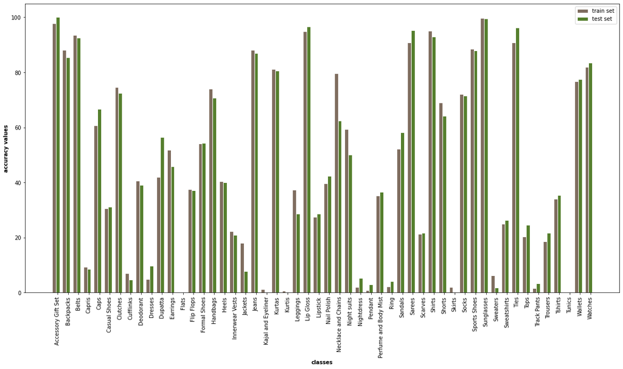

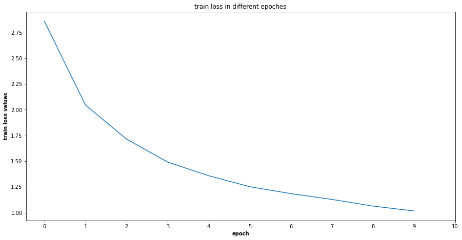

```python
train_acc_09, test_acc_09, average_losses_09 = check_learning_rates(0.09)
```

```python
def plot_test_accuracy_curve(learning_rate, accuracy):
  f, ax = plt.subplots(figsize=(10,5))
  plt.plot(learning_rate, accuracy)
  plt.xlabel('Learning Rate', fontweight='bold')
  plt.ylabel('Accuracy', fontweight='bold')
  plt.xticks(learning_rate, rotation = 90)
  plt.title('Accuracy for Different Learning Rates')
```

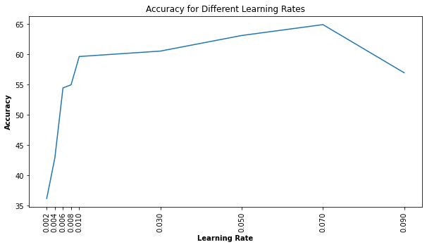

```python
learning_rates = [0.002, 0.004, 0.006, 0.008, 0.01, 0.03, 0.05, 0.07, 0.09]
accuracies = [test_acc_002, test_acc_004, test_acc_006, test_acc_008,
              test_acc_01, test_acc_03, test_acc_05, test_acc_07, test_acc_09]
plot_test_accuracy_curve(learning_rates, accuracies)
```

In this part different values of learning rates were used and accuracy for each of the values were obtained. The tested values are: 0.002, 0.004, 0.006, 0.008. 0.01, 0.03, 0.05, 0.07, 0.09. The best learning rate was 0.05. (Accuracy for 0.07 was higher but the practice is that the best learning rate is one on the way to the peak and not the peak itself)

#### **Optimum Learning Rate = 0.05**

```python
opt_lr = 0.05
```

### **6-b** : What happens for very large or very small learning rates?

**Learning Rate = 0.1**

```
Learning Rate =  0.1
epoch 1, train_loss: 2.960, time elapsed: 28.753372 seconds
epoch 2, train_loss: 2.170, time elapsed: 28.875652 seconds
epoch 3, train_loss: 1.859, time elapsed: 28.800361 seconds
epoch 4, train_loss: 1.607, time elapsed: 29.355835 seconds
epoch 5, train_loss: 1.449, time elapsed: 28.899991 seconds
epoch 6, train_loss: 1.324, time elapsed: 28.865768 seconds
epoch 7, train_loss: 1.220, time elapsed: 28.7807 seconds
epoch 8, train_loss: 1.156, time elapsed: 28.854859 seconds
epoch 9, train_loss: 1.097, time elapsed: 28.750809 seconds
epoch 10, train_loss: 1.043, time elapsed: 28.926237 seconds
total training time: 4.814 minutes

Accuracy:
Test:  61.060402684563755
Train:  61.149703010168125
```

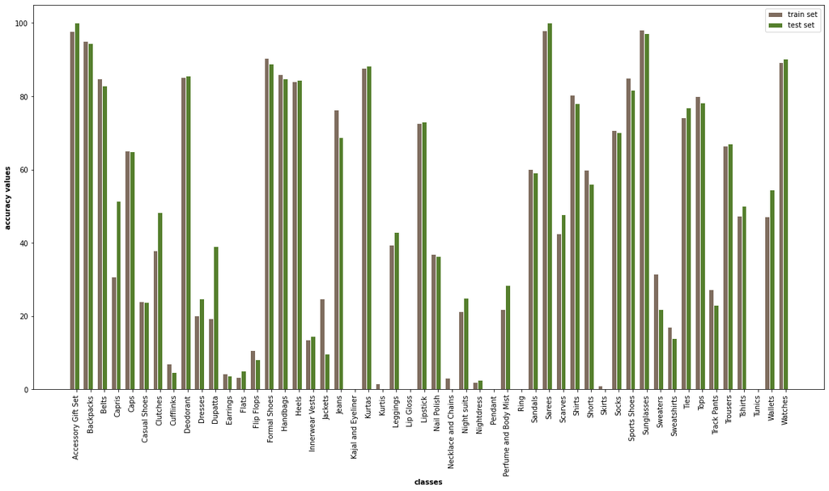

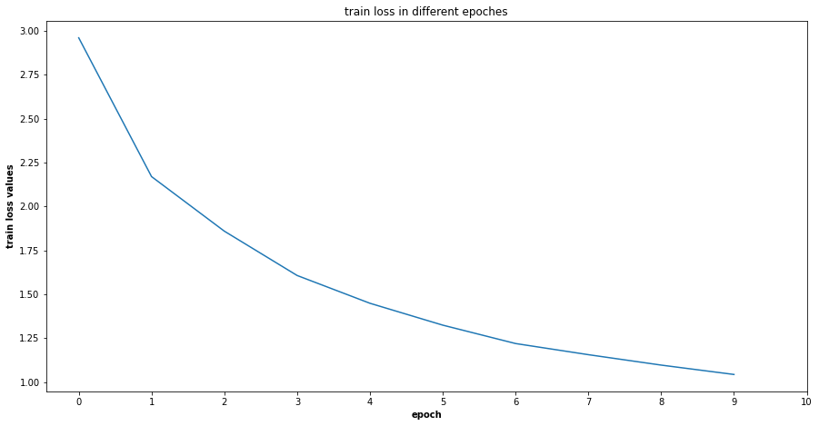

```python
train_acc_1, test_acc_1, average_losses_1 = check_learning_rates(0.1)
```

For larger learning rates (like 0.1) weights are updated faster therfore the training loss will get smaller faster however in this case it is probable that due to the larger step the minimum will get missed over and over again and never actually reach the minimum.

Here the accuracy has decreased a couple of percents due to the increase of learning rate.

**Learning Rate = 0.001**

```
Learning Rate =  0.001
epoch 1, train_loss: 3.872, time elapsed: 28.751709 seconds
epoch 2, train_loss: 3.570, time elapsed: 28.690692 seconds
epoch 3, train_loss: 3.449, time elapsed: 28.76032 seconds
epoch 4, train_loss: 3.424, time elapsed: 28.284896 seconds
epoch 5, train_loss: 3.398, time elapsed: 28.865335 seconds
epoch 6, train_loss: 3.355, time elapsed: 28.938688 seconds
epoch 7, train_loss: 3.276, time elapsed: 29.004059 seconds
epoch 8, train_loss: 3.147, time elapsed: 28.963724 seconds
epoch 9, train_loss: 3.005, time elapsed: 29.111945 seconds
epoch 10, train_loss: 2.893, time elapsed: 28.954232 seconds
total training time: 4.805 minutes

Accuracy:
Test:  23.503355704697988
Train:  23.128292895734756
```

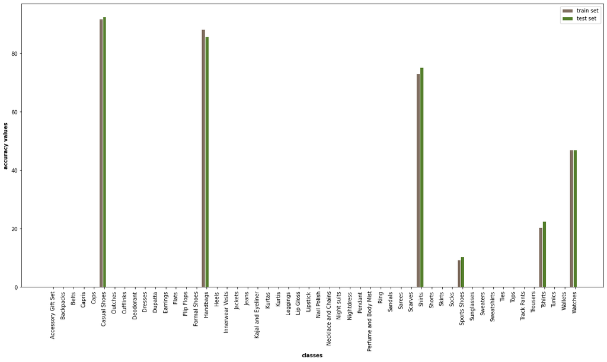

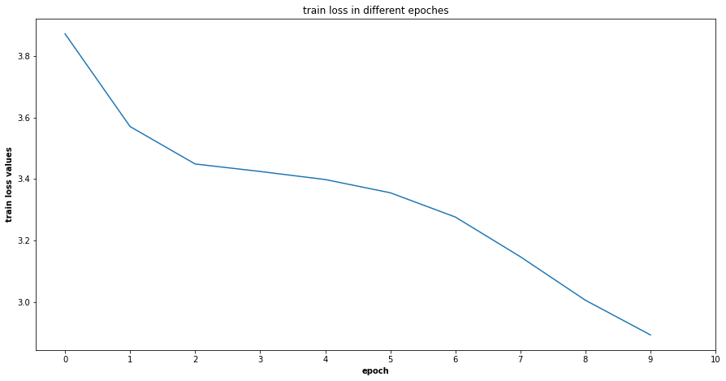

```python
train_acc_001, test_acc_001, average_losses_001 = check_learning_rates(0.001)
```

For smaller learning rate (like 0.001) the step size becomes very small therefore the convergence becomes slower and might even stop.

Here the accuracy has dropped significantly due to the decrease in the learning rate and it is also observable that the train losses get less with a much smaller rate.